# examples_1223

When $\sqrt{45}$ is simplified, it can be expressed as $p\sqrt{m}$, where $p$ and $m$ are both positive integers. Find $p$ and $m$.

$p=$

$m=$

Start with the given expression.
$$\sqrt{45}$$
I recommend prime factorization.
$$\sqrt{3\cdot3\cdot5}$$

Every pair of matching factors under the radical can be replaced with a single factor in front of the radical. More formally, we can apply the following 2 rules:

1. Square roots distribute over multiplication. $\sqrt{x\cdot y}\equiv \sqrt{x}\cdot\sqrt{y}$
2. The square root of a squared number is equivalent to the absolute value of that number. $\sqrt{z^2}~\equiv~|z|$

Applying those rules (or "bringing out repeating factors") leads to:

$$3\sqrt{5}$$

If necessary, evaluate any products to simplify.

$$3\sqrt{5}$$

So, $p=3$ and $m=5$.

When $\sqrt{275}$ is simplified, it can be expressed as $p\sqrt{m}$, where $p$ and $m$ are both positive integers. Find $p$ and $m$.

$p=$

$m=$

Start with the given expression.
$$\sqrt{275}$$
I recommend prime factorization.
$$\sqrt{5\cdot5\cdot11}$$

Every pair of matching factors under the radical can be replaced with a single factor in front of the radical. More formally, we can apply the following 2 rules:

1. Square roots distribute over multiplication. $\sqrt{x\cdot y}\equiv \sqrt{x}\cdot\sqrt{y}$
2. The square root of a squared number is equivalent to the absolute value of that number. $\sqrt{z^2}~\equiv~|z|$

Applying those rules (or "bringing out repeating factors") leads to:

$$5\sqrt{11}$$

If necessary, evaluate any products to simplify.

$$5\sqrt{11}$$

So, $p=5$ and $m=11$.

When $\sqrt{54}$ is simplified, it can be expressed as $p\sqrt{m}$, where $p$ and $m$ are both positive integers. Find $p$ and $m$.

$p=$

$m=$

Start with the given expression.
$$\sqrt{54}$$
I recommend prime factorization.
$$\sqrt{2\cdot3\cdot3\cdot3}$$

Every pair of matching factors under the radical can be replaced with a single factor in front of the radical. More formally, we can apply the following 2 rules:

1. Square roots distribute over multiplication. $\sqrt{x\cdot y}\equiv \sqrt{x}\cdot\sqrt{y}$
2. The square root of a squared number is equivalent to the absolute value of that number. $\sqrt{z^2}~\equiv~|z|$

Applying those rules (or "bringing out repeating factors") leads to:

$$3\sqrt{2\cdot3}$$

If necessary, evaluate any products to simplify.

$$3\sqrt{6}$$

So, $p=3$ and $m=6$.

When $\sqrt{99}$ is simplified, it can be expressed as $p\sqrt{m}$, where $p$ and $m$ are both positive integers. Find $p$ and $m$.

$p=$

$m=$

Start with the given expression.
$$\sqrt{99}$$
I recommend prime factorization.
$$\sqrt{3\cdot3\cdot11}$$

Every pair of matching factors under the radical can be replaced with a single factor in front of the radical. More formally, we can apply the following 2 rules:

1. Square roots distribute over multiplication. $\sqrt{x\cdot y}\equiv \sqrt{x}\cdot\sqrt{y}$
2. The square root of a squared number is equivalent to the absolute value of that number. $\sqrt{z^2}~\equiv~|z|$

Applying those rules (or "bringing out repeating factors") leads to:

$$3\sqrt{11}$$

If necessary, evaluate any products to simplify.

$$3\sqrt{11}$$

So, $p=3$ and $m=11$.

When $\sqrt{40}$ is simplified, it can be expressed as $p\sqrt{m}$, where $p$ and $m$ are both positive integers. Find $p$ and $m$.

$p=$

$m=$

Start with the given expression.
$$\sqrt{40}$$
I recommend prime factorization.
$$\sqrt{2\cdot2\cdot2\cdot5}$$

Every pair of matching factors under the radical can be replaced with a single factor in front of the radical. More formally, we can apply the following 2 rules:

1. Square roots distribute over multiplication. $\sqrt{x\cdot y}\equiv \sqrt{x}\cdot\sqrt{y}$
2. The square root of a squared number is equivalent to the absolute value of that number. $\sqrt{z^2}~\equiv~|z|$

Applying those rules (or "bringing out repeating factors") leads to:

$$2\sqrt{2\cdot5}$$

If necessary, evaluate any products to simplify.

$$2\sqrt{10}$$

So, $p=2$ and $m=10$.

A parabola is randomly generated by randomly choosing parameters $a$, $h$, and $k$ in the vertex-form equation:

$$y~=~a(x-h)^2+k$$

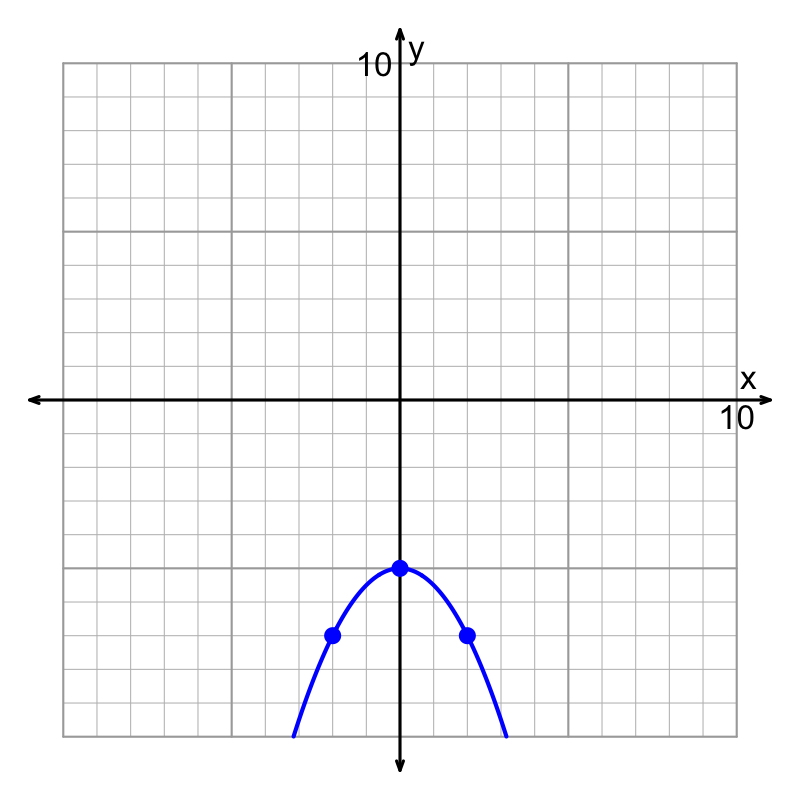

Find the parameters.

- $a=$
- $h=$
- $k=$

How many $x$-intercepts does the parabola have? (Some might not show on the graph.)

To find $a$, you might use [this reference](https://artockthedino.github.io/algtwo2026/u06/1218/Stretched_Parabolas_Reference.html). Notice, if $a$ is negative, the parabola faces down, and if $a$ is positive, the parabola faces up. If $|a|$ is bigger than 1, then the parent $y=x^2$ is stretched vertically. If $|a|$ is less than 1, then the parent $y=x^2$ is shrunk vertically. To find the exact value, you need to look at precisely where the curve intersects the lattice points.

To find $h$ and $k$, you can just find the coordinates of the vertex.

To determine the number of roots...

- If the vertex is on the $x$ axis, there is one root.
- If the parabola opens **up** and the vertex is **above** the $x$ axis, then 0 roots.
- If the parabola opens **down** and the vertex is **above** the $x$ axis, then 2 roots.
- If the parabola opens **up** and the vertex is **below** the $x$ axis, then 2 roots.
- If the parabola opens **down** and the vertex is **below** the $x$ axis, then 0 roots.

A parabola is randomly generated by randomly choosing parameters $a$, $h$, and $k$ in the vertex-form equation:

$$y~=~a(x-h)^2+k$$

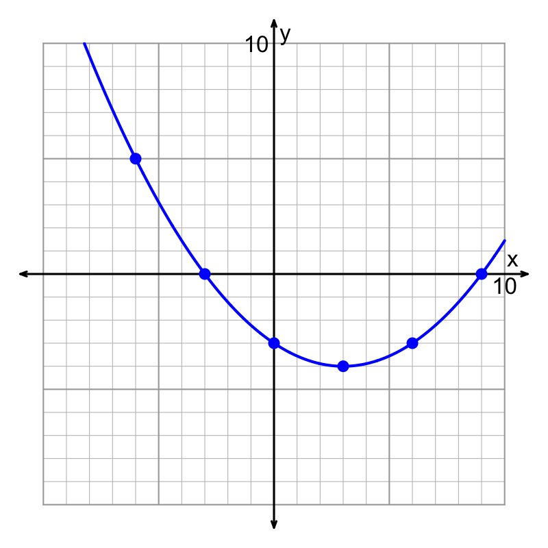

Find the parameters.

- $a=$
- $h=$
- $k=$

How many $x$-intercepts does the parabola have? (Some might not show on the graph.)

To find $a$, you might use [this reference](https://artockthedino.github.io/algtwo2026/u06/1218/Stretched_Parabolas_Reference.html). Notice, if $a$ is negative, the parabola faces down, and if $a$ is positive, the parabola faces up. If $|a|$ is bigger than 1, then the parent $y=x^2$ is stretched vertically. If $|a|$ is less than 1, then the parent $y=x^2$ is shrunk vertically. To find the exact value, you need to look at precisely where the curve intersects the lattice points.

To find $h$ and $k$, you can just find the coordinates of the vertex.

To determine the number of roots...

- If the vertex is on the $x$ axis, there is one root.
- If the parabola opens **up** and the vertex is **above** the $x$ axis, then 0 roots.
- If the parabola opens **down** and the vertex is **above** the $x$ axis, then 2 roots.
- If the parabola opens **up** and the vertex is **below** the $x$ axis, then 2 roots.
- If the parabola opens **down** and the vertex is **below** the $x$ axis, then 0 roots.

A parabola is randomly generated by randomly choosing parameters $a$, $h$, and $k$ in the vertex-form equation:

$$y~=~a(x-h)^2+k$$

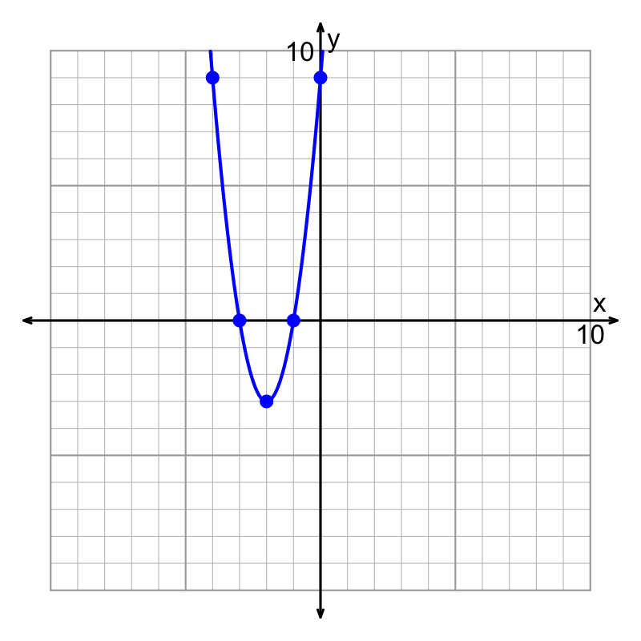

Find the parameters.

- $a=$
- $h=$
- $k=$

How many $x$-intercepts does the parabola have? (Some might not show on the graph.)

To find $a$, you might use [this reference](https://artockthedino.github.io/algtwo2026/u06/1218/Stretched_Parabolas_Reference.html). Notice, if $a$ is negative, the parabola faces down, and if $a$ is positive, the parabola faces up. If $|a|$ is bigger than 1, then the parent $y=x^2$ is stretched vertically. If $|a|$ is less than 1, then the parent $y=x^2$ is shrunk vertically. To find the exact value, you need to look at precisely where the curve intersects the lattice points.

To find $h$ and $k$, you can just find the coordinates of the vertex.

To determine the number of roots...

- If the vertex is on the $x$ axis, there is one root.
- If the parabola opens **up** and the vertex is **above** the $x$ axis, then 0 roots.
- If the parabola opens **down** and the vertex is **above** the $x$ axis, then 2 roots.
- If the parabola opens **up** and the vertex is **below** the $x$ axis, then 2 roots.
- If the parabola opens **down** and the vertex is **below** the $x$ axis, then 0 roots.

A parabola is randomly generated by randomly choosing parameters $a$, $h$, and $k$ in the vertex-form equation:

$$y~=~a(x-h)^2+k$$

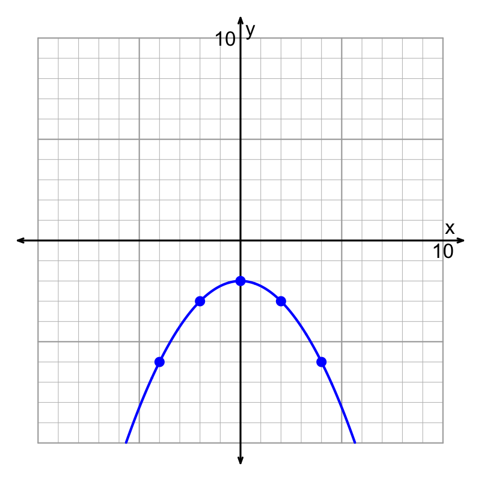

Find the parameters.

- $a=$
- $h=$
- $k=$

How many $x$-intercepts does the parabola have? (Some might not show on the graph.)

To find $a$, you might use [this reference](https://artockthedino.github.io/algtwo2026/u06/1218/Stretched_Parabolas_Reference.html). Notice, if $a$ is negative, the parabola faces down, and if $a$ is positive, the parabola faces up. If $|a|$ is bigger than 1, then the parent $y=x^2$ is stretched vertically. If $|a|$ is less than 1, then the parent $y=x^2$ is shrunk vertically. To find the exact value, you need to look at precisely where the curve intersects the lattice points.

To find $h$ and $k$, you can just find the coordinates of the vertex.

To determine the number of roots...

- If the vertex is on the $x$ axis, there is one root.
- If the parabola opens **up** and the vertex is **above** the $x$ axis, then 0 roots.
- If the parabola opens **down** and the vertex is **above** the $x$ axis, then 2 roots.
- If the parabola opens **up** and the vertex is **below** the $x$ axis, then 2 roots.
- If the parabola opens **down** and the vertex is **below** the $x$ axis, then 0 roots.

A parabola is randomly generated by randomly choosing parameters $a$, $h$, and $k$ in the vertex-form equation:

$$y~=~a(x-h)^2+k$$

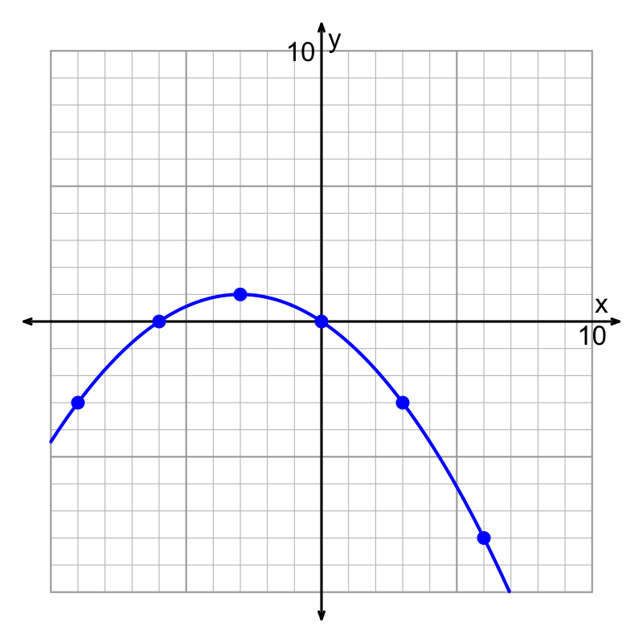

Find the parameters.

- $a=$
- $h=$
- $k=$

How many $x$-intercepts does the parabola have? (Some might not show on the graph.)

To find $a$, you might use [this reference](https://artockthedino.github.io/algtwo2026/u06/1218/Stretched_Parabolas_Reference.html). Notice, if $a$ is negative, the parabola faces down, and if $a$ is positive, the parabola faces up. If $|a|$ is bigger than 1, then the parent $y=x^2$ is stretched vertically. If $|a|$ is less than 1, then the parent $y=x^2$ is shrunk vertically. To find the exact value, you need to look at precisely where the curve intersects the lattice points.

To find $h$ and $k$, you can just find the coordinates of the vertex.

To determine the number of roots...

- If the vertex is on the $x$ axis, there is one root.
- If the parabola opens **up** and the vertex is **above** the $x$ axis, then 0 roots.
- If the parabola opens **down** and the vertex is **above** the $x$ axis, then 2 roots.
- If the parabola opens **up** and the vertex is **below** the $x$ axis, then 2 roots.
- If the parabola opens **down** and the vertex is **below** the $x$ axis, then 0 roots.

A quadratic function, with two [real](https://en.wikipedia.org/wiki/Real_number) [roots](https://en.wikipedia.org/wiki/Zero_of_a_function), is graphed below.

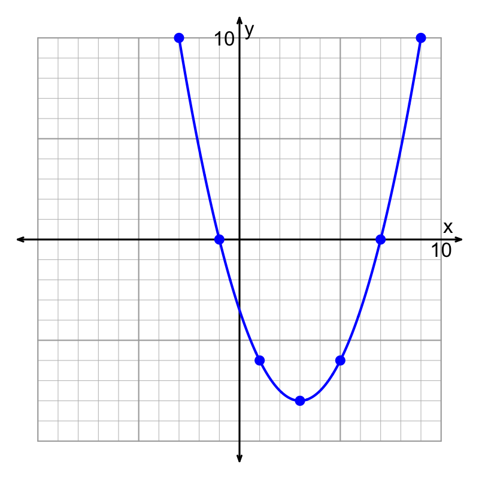

What equation represents the function in factored form?

$y=\frac{-1}{2}(x-{7})(x-{1})$$y=\frac{-1}{2}(x-{7})(x+{1})$$y=\frac{-1}{2}(x+{7})(x-{1})$$y=\frac{-1}{2}(x+{7})(x+{1})$$y=\frac{-1}{9}(x-{7})(x-{1})$$y=\frac{-1}{9}(x-{7})(x+{1})$$y=\frac{-1}{9}(x+{7})(x-{1})$$y=\frac{-1}{9}(x+{7})(x+{1})$$y=\frac{1}{2}(x-{7})(x-{1})$$y=\frac{1}{2}(x-{7})(x+{1})$$y=\frac{1}{2}(x+{7})(x-{1})$$y=\frac{1}{2}(x+{7})(x+{1})$$y=\frac{1}{9}(x-{7})(x-{1})$$y=\frac{1}{9}(x-{7})(x+{1})$$y=\frac{1}{9}(x+{7})(x-{1})$$y=\frac{1}{9}(x+{7})(x+{1})$

The correct answer is:
$$y=\frac{1}{2}(x-{7})(x+{1})$$

You can determine $a$ by using [this reference sheet](https://artockthedino.github.io/algtwo2026/u06/1218/Stretched_Parabolas_Reference.html). You also need to remember that if $a<0$, then the parabola opens downward.

The roots are at $(-1,0)$ and $(7,0)$. Thus, we could say $r=7$ and $s=-1$ (or the other way around). We put those parameters into factored-form equation, $y=a(x-r)(x-s)$, to get...

$$y=\frac{1}{2}(x-{7})(x+{1})$$

A quadratic function, with two [real](https://en.wikipedia.org/wiki/Real_number) [roots](https://en.wikipedia.org/wiki/Zero_of_a_function), is graphed below.

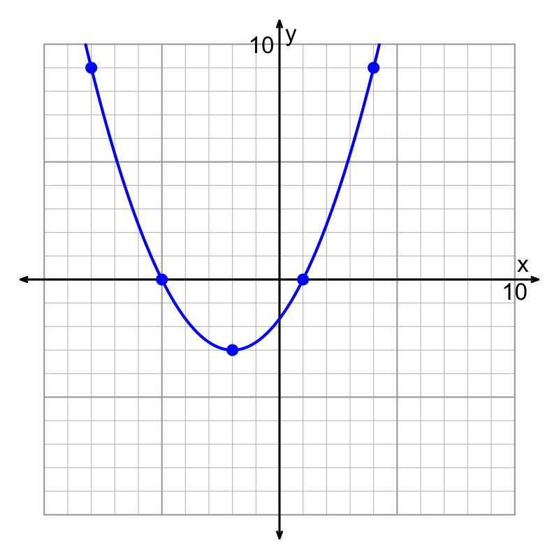

What equation represents the function in factored form?

$y=\frac{-1}{3}(x-{1})(x-{5})$$y=\frac{-1}{3}(x-{1})(x+{5})$$y=\frac{-1}{3}(x+{1})(x-{5})$$y=\frac{-1}{3}(x+{1})(x+{5})$$y=\frac{-1}{4}(x-{1})(x-{5})$$y=\frac{-1}{4}(x-{1})(x+{5})$$y=\frac{-1}{4}(x+{1})(x-{5})$$y=\frac{-1}{4}(x+{1})(x+{5})$$y=\frac{1}{3}(x-{1})(x-{5})$$y=\frac{1}{3}(x-{1})(x+{5})$$y=\frac{1}{3}(x+{1})(x-{5})$$y=\frac{1}{3}(x+{1})(x+{5})$$y=\frac{1}{4}(x-{1})(x-{5})$$y=\frac{1}{4}(x-{1})(x+{5})$$y=\frac{1}{4}(x+{1})(x-{5})$$y=\frac{1}{4}(x+{1})(x+{5})$

The correct answer is:
$$y=\frac{1}{3}(x-{1})(x+{5})$$

You can determine $a$ by using [this reference sheet](https://artockthedino.github.io/algtwo2026/u06/1218/Stretched_Parabolas_Reference.html). You also need to remember that if $a<0$, then the parabola opens downward.

The roots are at $(-5,0)$ and $(1,0)$. Thus, we could say $r=1$ and $s=-5$ (or the other way around). We put those parameters into factored-form equation, $y=a(x-r)(x-s)$, to get...

$$y=\frac{1}{3}(x-{1})(x+{5})$$

A quadratic function, with two [real](https://en.wikipedia.org/wiki/Real_number) [roots](https://en.wikipedia.org/wiki/Zero_of_a_function), is graphed below.

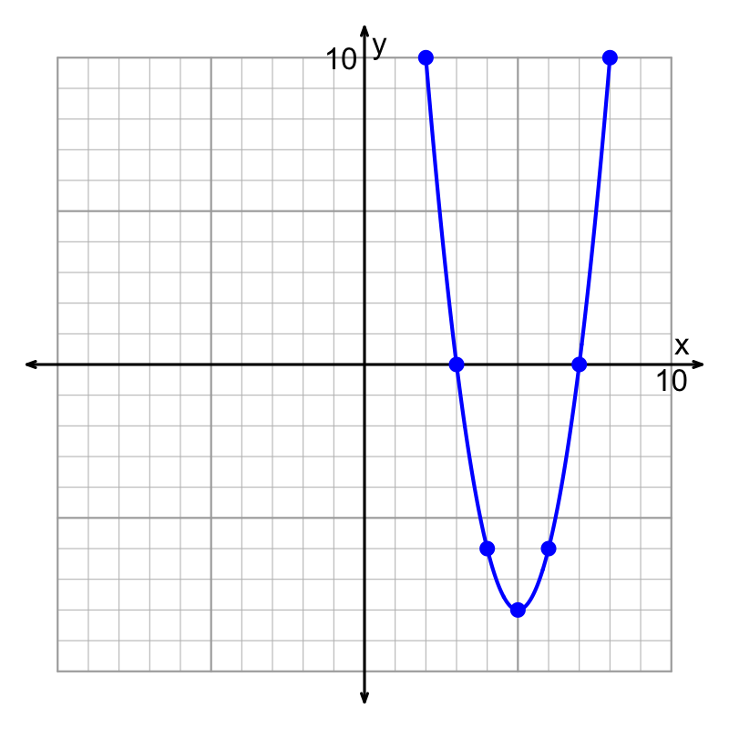

What equation represents the function in factored form?

$y=-2(x-{7})(x-{3})$$y=-2(x-{7})(x+{3})$$y=-2(x+{7})(x-{3})$$y=-2(x+{7})(x+{3})$$y=\frac{-1}{4}(x-{7})(x-{3})$$y=\frac{-1}{4}(x-{7})(x+{3})$$y=\frac{-1}{4}(x+{7})(x-{3})$$y=\frac{-1}{4}(x+{7})(x+{3})$$y=\frac{1}{4}(x-{7})(x-{3})$$y=\frac{1}{4}(x-{7})(x+{3})$$y=\frac{1}{4}(x+{7})(x-{3})$$y=\frac{1}{4}(x+{7})(x+{3})$$y=2(x-{7})(x-{3})$$y=2(x-{7})(x+{3})$$y=2(x+{7})(x-{3})$$y=2(x+{7})(x+{3})$

The correct answer is:
$$y=2(x-{7})(x-{3})$$

You can determine $a$ by using [this reference sheet](https://artockthedino.github.io/algtwo2026/u06/1218/Stretched_Parabolas_Reference.html). You also need to remember that if $a<0$, then the parabola opens downward.

The roots are at $(3,0)$ and $(7,0)$. Thus, we could say $r=7$ and $s=3$ (or the other way around). We put those parameters into factored-form equation, $y=a(x-r)(x-s)$, to get...

$$y=2(x-{7})(x-{3})$$

A quadratic function, with two [real](https://en.wikipedia.org/wiki/Real_number) [roots](https://en.wikipedia.org/wiki/Zero_of_a_function), is graphed below.

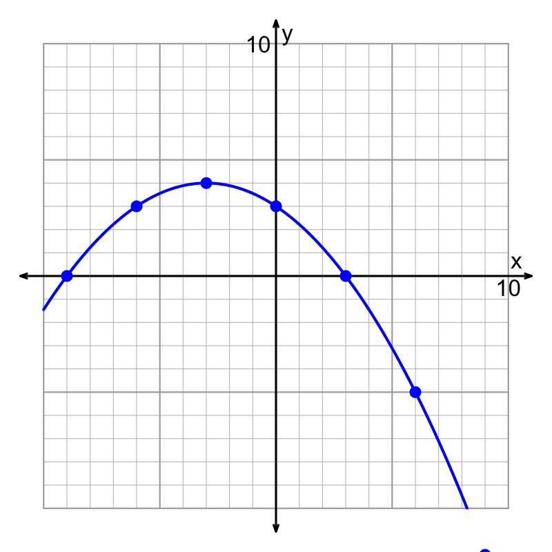

What equation represents the function in factored form?

$y=-2(x-{9})(x-{3})$$y=-2(x-{9})(x+{3})$$y=-2(x+{9})(x-{3})$$y=-2(x+{9})(x+{3})$$y=\frac{-1}{9}(x-{9})(x-{3})$$y=\frac{-1}{9}(x-{9})(x+{3})$$y=\frac{-1}{9}(x+{9})(x-{3})$$y=\frac{-1}{9}(x+{9})(x+{3})$$y=\frac{1}{9}(x-{9})(x-{3})$$y=\frac{1}{9}(x-{9})(x+{3})$$y=\frac{1}{9}(x+{9})(x-{3})$$y=\frac{1}{9}(x+{9})(x+{3})$$y=2(x-{9})(x-{3})$$y=2(x-{9})(x+{3})$$y=2(x+{9})(x-{3})$$y=2(x+{9})(x+{3})$

The correct answer is:
$$y=\frac{-1}{9}(x+{9})(x-{3})$$

You can determine $a$ by using [this reference sheet](https://artockthedino.github.io/algtwo2026/u06/1218/Stretched_Parabolas_Reference.html). You also need to remember that if $a<0$, then the parabola opens downward.

The roots are at $(-9,0)$ and $(3,0)$. Thus, we could say $r=-9$ and $s=3$ (or the other way around). We put those parameters into factored-form equation, $y=a(x-r)(x-s)$, to get...

$$y=\frac{-1}{9}(x+{9})(x-{3})$$

A quadratic function, with two [real](https://en.wikipedia.org/wiki/Real_number) [roots](https://en.wikipedia.org/wiki/Zero_of_a_function), is graphed below.

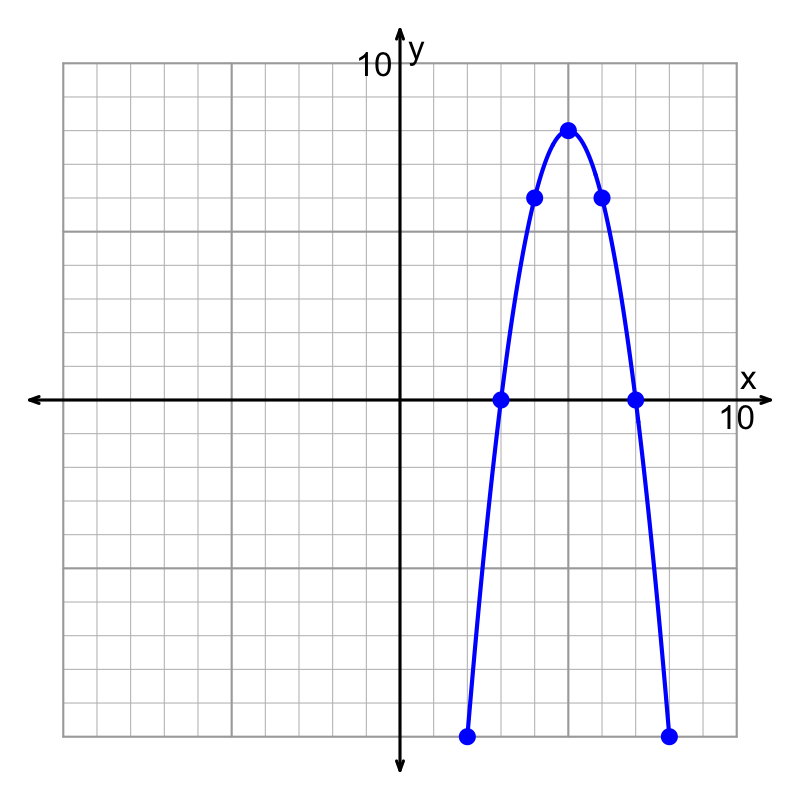

What equation represents the function in factored form?

$y=-2(x-{3})(x-{7})$$y=-2(x-{3})(x+{7})$$y=-2(x+{3})(x-{7})$$y=-2(x+{3})(x+{7})$$y=\frac{-1}{2}(x-{3})(x-{7})$$y=\frac{-1}{2}(x-{3})(x+{7})$$y=\frac{-1}{2}(x+{3})(x-{7})$$y=\frac{-1}{2}(x+{3})(x+{7})$$y=\frac{1}{2}(x-{3})(x-{7})$$y=\frac{1}{2}(x-{3})(x+{7})$$y=\frac{1}{2}(x+{3})(x-{7})$$y=\frac{1}{2}(x+{3})(x+{7})$$y=2(x-{3})(x-{7})$$y=2(x-{3})(x+{7})$$y=2(x+{3})(x-{7})$$y=2(x+{3})(x+{7})$

The correct answer is:
$$y=-2(x-{3})(x-{7})$$

You can determine $a$ by using [this reference sheet](https://artockthedino.github.io/algtwo2026/u06/1218/Stretched_Parabolas_Reference.html). You also need to remember that if $a<0$, then the parabola opens downward.

The roots are at $(3,0)$ and $(7,0)$. Thus, we could say $r=3$ and $s=7$ (or the other way around). We put those parameters into factored-form equation, $y=a(x-r)(x-s)$, to get...

$$y=-2(x-{3})(x-{7})$$

Consider the quadratic function graphed below.

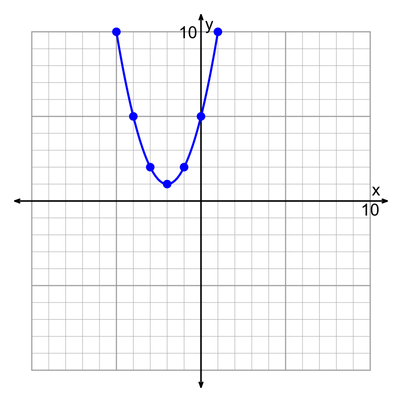

Find parameters $a$, $b$, and $c$, such that the above curve represents $y=ax^2+bx+c$.

- $a=$
- $b=$
- $c=$

First, [based on the spacing of lattice-point intersections near the vertex](https://artockthedino.github.io/algtwo2026/u06/1218/Stretched_Parabolas_Reference.html), and also the up/down orientation, we can determine $a$.

$$a~=~1$$

Next, identify the location of the vertex is $(-2,1)$, so $h=-2$. We know that $h=\frac{-b}{2a}$, so with a bit of algebra, we also know that $b=-2ah$.

$$b~=~-2(1)(-2)$$
$$b~=~4$$

Lastly, getting $c$ is easy. Notice, if $x=0$, then $y=c$. Thus, we just need to find the $y$ intercept to get $c$.

$$c=5$$

The function:

$$y=x^{2}+{4}x+{5}$$

Consider the quadratic function graphed below.

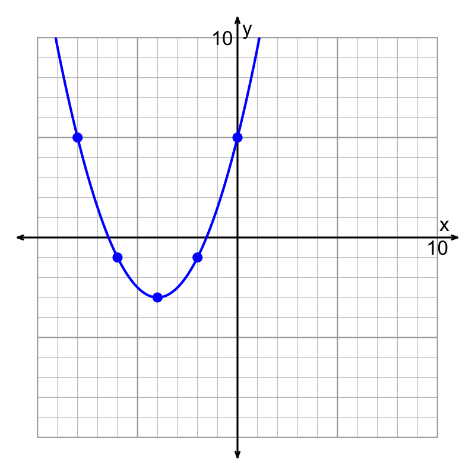

Find parameters $a$, $b$, and $c$, such that the above curve represents $y=ax^2+bx+c$.

- $a=$
- $b=$
- $c=$

First, [based on the spacing of lattice-point intersections near the vertex](https://artockthedino.github.io/algtwo2026/u06/1218/Stretched_Parabolas_Reference.html), and also the up/down orientation, we can determine $a$.

$$a~=~\frac{1}{2}$$

Next, identify the location of the vertex is $(-4,-3)$, so $h=-4$. We know that $h=\frac{-b}{2a}$, so with a bit of algebra, we also know that $b=-2ah$.

$$b~=~-2(1/2)(-4)$$
$$b~=~4$$

Lastly, getting $c$ is easy. Notice, if $x=0$, then $y=c$. Thus, we just need to find the $y$ intercept to get $c$.

$$c=5$$

The function:

$$y={\frac{1}{2}}x^{2}+{4}x+{5}$$

Consider the quadratic function graphed below.

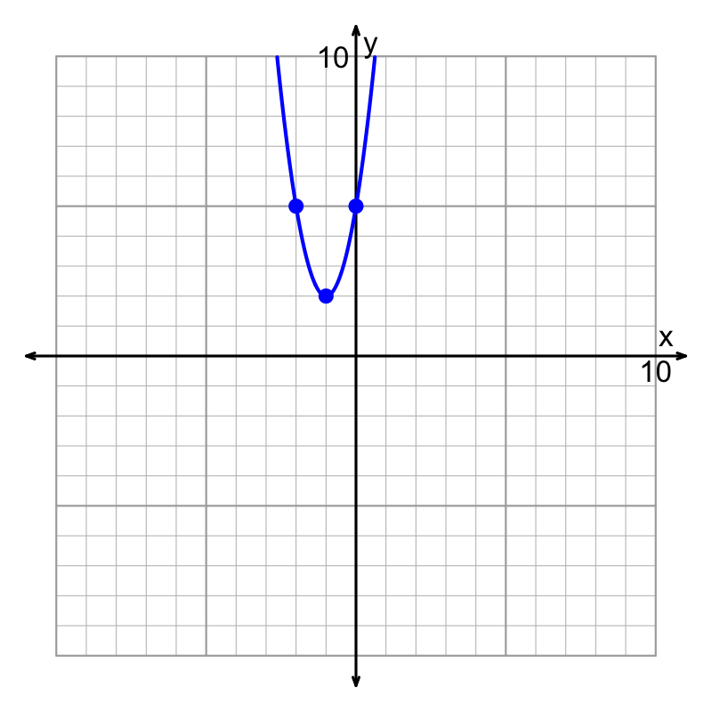

Find parameters $a$, $b$, and $c$, such that the above curve represents $y=ax^2+bx+c$.

- $a=$
- $b=$
- $c=$

First, [based on the spacing of lattice-point intersections near the vertex](https://artockthedino.github.io/algtwo2026/u06/1218/Stretched_Parabolas_Reference.html), and also the up/down orientation, we can determine $a$.

$$a~=~3$$

Next, identify the location of the vertex is $(-1,2)$, so $h=-1$. We know that $h=\frac{-b}{2a}$, so with a bit of algebra, we also know that $b=-2ah$.

$$b~=~-2(3)(-1)$$
$$b~=~6$$

Lastly, getting $c$ is easy. Notice, if $x=0$, then $y=c$. Thus, we just need to find the $y$ intercept to get $c$.

$$c=5$$

The function:

$$y={3}x^{2}+{6}x+{5}$$

Consider the quadratic function graphed below.

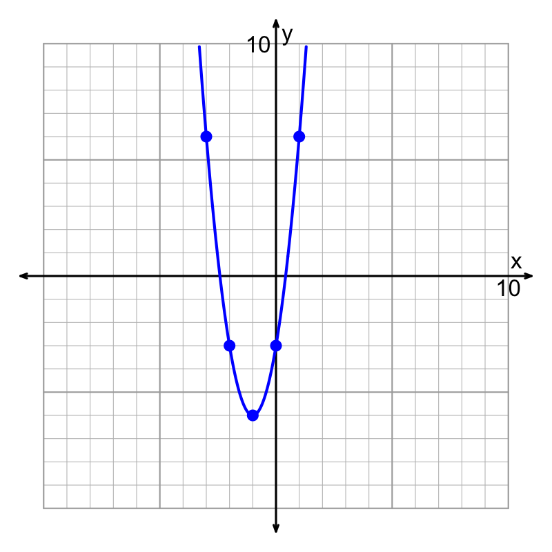

Find parameters $a$, $b$, and $c$, such that the above curve represents $y=ax^2+bx+c$.

- $a=$
- $b=$
- $c=$

First, [based on the spacing of lattice-point intersections near the vertex](https://artockthedino.github.io/algtwo2026/u06/1218/Stretched_Parabolas_Reference.html), and also the up/down orientation, we can determine $a$.

$$a~=~3$$

Next, identify the location of the vertex is $(-1,-6)$, so $h=-1$. We know that $h=\frac{-b}{2a}$, so with a bit of algebra, we also know that $b=-2ah$.

$$b~=~-2(3)(-1)$$
$$b~=~6$$

Lastly, getting $c$ is easy. Notice, if $x=0$, then $y=c$. Thus, we just need to find the $y$ intercept to get $c$.

$$c=-3$$

The function:

$$y={3}x^{2}+{6}x-{3}$$

Consider the quadratic function graphed below.

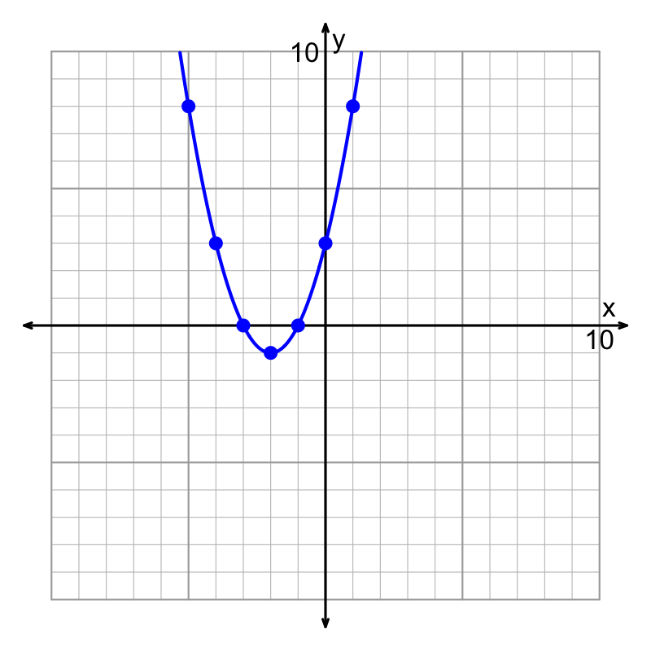

Find parameters $a$, $b$, and $c$, such that the above curve represents $y=ax^2+bx+c$.

- $a=$
- $b=$
- $c=$

First, [based on the spacing of lattice-point intersections near the vertex](https://artockthedino.github.io/algtwo2026/u06/1218/Stretched_Parabolas_Reference.html), and also the up/down orientation, we can determine $a$.

$$a~=~1$$

Next, identify the location of the vertex is $(-2,-1)$, so $h=-2$. We know that $h=\frac{-b}{2a}$, so with a bit of algebra, we also know that $b=-2ah$.

$$b~=~-2(1)(-2)$$
$$b~=~4$$

Lastly, getting $c$ is easy. Notice, if $x=0$, then $y=c$. Thus, we just need to find the $y$ intercept to get $c$.

$$c=3$$

The function:

$$y=x^{2}+{4}x+{3}$$

Calculate the [discriminant](https://en.wikipedia.org/wiki/Quadratic_equation#Discriminant) of the following quadratic function:

$$y~=~{4}x^{2}-{15}x-{11}$$

Identify the coefficients.

$$a=4$$
$$b=-15$$
$$c=-11$$

Use the formula for the disciminant.

$$D=(-15)^2-4(4)(-11)$$

$$D=401$$

The discriminant, $D=401$, is positive, so there are two $x$-intercepts.

Calculate the [discriminant](https://en.wikipedia.org/wiki/Quadratic_equation#Discriminant) of the following quadratic function:

$$y~=~{15}x^{2}-{15}x+{3}$$

Identify the coefficients.

$$a=15$$
$$b=-15$$
$$c=3$$

Use the formula for the disciminant.

$$D=(-15)^2-4(15)(3)$$

$$D=45$$

The discriminant, $D=45$, is positive, so there are two $x$-intercepts.

Calculate the [discriminant](https://en.wikipedia.org/wiki/Quadratic_equation#Discriminant) of the following quadratic function:

$$y~=~{14}x^{2}-{2}x+{16}$$

Identify the coefficients.

$$a=14$$
$$b=-2$$
$$c=16$$

Use the formula for the disciminant.

$$D=(-2)^2-4(14)(16)$$

$$D=-892$$

The discriminant, $D=-892$, is negative, so there are no $x$-intercepts.

Calculate the [discriminant](https://en.wikipedia.org/wiki/Quadratic_equation#Discriminant) of the following quadratic function:

$$y~=~{8}x^{2}+{16}x+{8}$$

Identify the coefficients.

$$a=8$$
$$b=16$$
$$c=8$$

Use the formula for the disciminant.

$$D=(16)^2-4(8)(8)$$

$$D=0$$

The discriminant, $D=0$, is zero, so there is one $x$-intercept.

Calculate the [discriminant](https://en.wikipedia.org/wiki/Quadratic_equation#Discriminant) of the following quadratic function:

$$y~=~{2}x^{2}+{16}x-{7}$$

Identify the coefficients.

$$a=2$$
$$b=16$$
$$c=-7$$

Use the formula for the disciminant.

$$D=(16)^2-4(2)(-7)$$

$$D=312$$

The discriminant, $D=312$, is positive, so there are two $x$-intercepts.

Jordan is selling widgets. Each widget costs Jordan $2.95 to produce. Per week, the number of widgets ($w$) Jordan sells is a linear function of the price ($x$) Jordan charges per widget.
$$w=8500-400x$$

If Jordan wishes to maximize profit, what price should he charge per widget?

$x_{\text{optimal}}~=~?$

Construct the weekly profit function by multiplying the per-widget profit by the number of widgets sold per week.

$$P=(x-2.95)\cdot(8500-400x)$$

Expand (by FOIL or box) the profit function.

$$P=(x-2.95)\cdot(8500-400x)$$

$$P=8500x-400x^2-25075+1180x$$

Combine like terms, and put into standard order.

$$P=-400x^2+9680x-25075$$

Notice if we graphed this function, it would be a downward facing parabola. Thus, the vertex would represent the maximizing of profit. Because the question asks for the optimal price, we need to find $h$.

$$h=\frac{-b}{2a}$$

$$h=\frac{-9680}{2(-400)}$$

$$h=12.1$$

Thus, $x_{\text{optimal}}=12.10$, and so Jordan should charge $12.10 per widget.

Jordan is selling widgets. Each widget costs Jordan $0.12 to produce. Per week, the number of widgets ($w$) Jordan sells is a linear function of the price ($x$) Jordan charges per widget.
$$w=6900-6900x$$

If Jordan wishes to maximize profit, what price should he charge per widget?

$x_{\text{optimal}}~=~?$

Construct the weekly profit function by multiplying the per-widget profit by the number of widgets sold per week.

$$P=(x-0.12)\cdot(6900-6900x)$$

Expand (by FOIL or box) the profit function.

$$P=(x-0.12)\cdot(6900-6900x)$$

$$P=6900x-6900x^2-828+828x$$

Combine like terms, and put into standard order.

$$P=-6900x^2+7728x-828$$

Notice if we graphed this function, it would be a downward facing parabola. Thus, the vertex would represent the maximizing of profit. Because the question asks for the optimal price, we need to find $h$.

$$h=\frac{-b}{2a}$$

$$h=\frac{-7728}{2(-6900)}$$

$$h=0.56$$

Thus, $x_{\text{optimal}}=0.56$, and so Jordan should charge $0.56 per widget.

Jordan is selling widgets. Each widget costs Jordan $0.09 to produce. Per week, the number of widgets ($w$) Jordan sells is a linear function of the price ($x$) Jordan charges per widget.
$$w=7200-5760x$$

If Jordan wishes to maximize profit, what price should he charge per widget?

$x_{\text{optimal}}~=~?$

Construct the weekly profit function by multiplying the per-widget profit by the number of widgets sold per week.

$$P=(x-0.09)\cdot(7200-5760x)$$

Expand (by FOIL or box) the profit function.

$$P=(x-0.09)\cdot(7200-5760x)$$

$$P=7200x-5760x^2-648+518.4x$$

Combine like terms, and put into standard order.

$$P=-5760x^2+7718.4x-648$$

Notice if we graphed this function, it would be a downward facing parabola. Thus, the vertex would represent the maximizing of profit. Because the question asks for the optimal price, we need to find $h$.

$$h=\frac{-b}{2a}$$

$$h=\frac{-7718.4}{2(-5760)}$$

$$h=0.67$$

Thus, $x_{\text{optimal}}=0.67$, and so Jordan should charge $0.67 per widget.

Jordan is selling widgets. Each widget costs Jordan $2.10 to produce. Per week, the number of widgets ($w$) Jordan sells is a linear function of the price ($x$) Jordan charges per widget.
$$w=9600-1280x$$

If Jordan wishes to maximize profit, what price should he charge per widget?

$x_{\text{optimal}}~=~?$

Construct the weekly profit function by multiplying the per-widget profit by the number of widgets sold per week.

$$P=(x-2.10)\cdot(9600-1280x)$$

Expand (by FOIL or box) the profit function.

$$P=(x-2.10)\cdot(9600-1280x)$$

$$P=9600x-1280x^2-20160+2688x$$

Combine like terms, and put into standard order.

$$P=-1280x^2+12288x-20160$$

Notice if we graphed this function, it would be a downward facing parabola. Thus, the vertex would represent the maximizing of profit. Because the question asks for the optimal price, we need to find $h$.

$$h=\frac{-b}{2a}$$

$$h=\frac{-12288}{2(-1280)}$$

$$h=4.8$$

Thus, $x_{\text{optimal}}=4.80$, and so Jordan should charge $4.80 per widget.

Jordan is selling widgets. Each widget costs Jordan $4.46 to produce. Per week, the number of widgets ($w$) Jordan sells is a linear function of the price ($x$) Jordan charges per widget.
$$w=6400-512x$$

If Jordan wishes to maximize profit, what price should he charge per widget?

$x_{\text{optimal}}~=~?$

Construct the weekly profit function by multiplying the per-widget profit by the number of widgets sold per week.

$$P=(x-4.46)\cdot(6400-512x)$$

Expand (by FOIL or box) the profit function.

$$P=(x-4.46)\cdot(6400-512x)$$

$$P=6400x-512x^2-28544+2283.52x$$

Combine like terms, and put into standard order.

$$P=-512x^2+8683.52x-28544$$

Notice if we graphed this function, it would be a downward facing parabola. Thus, the vertex would represent the maximizing of profit. Because the question asks for the optimal price, we need to find $h$.

$$h=\frac{-b}{2a}$$

$$h=\frac{-8683.52}{2(-512)}$$

$$h=8.48$$

Thus, $x_{\text{optimal}}=8.48$, and so Jordan should charge $8.48 per widget.